# Effect of mutualist partner identity on plant demography - Bruna - 2014 - Ecology - Wiley Online Library

[Ecology](https://esajournals.onlinelibrary.wiley.com/journal/19399170)

[Volume 95, Issue 12](https://esajournals.onlinelibrary.wiley.com/toc/19399170/2014/95/12) p. 3237-3243

Report

Free Access

# Effect of mutualist partner identity on plant demography

[Emilio M. Bruna](https://esajournals.onlinelibrary.wiley.com/action/doSearch?ContribAuthorRaw=Bruna%2C+Emilio+M),

E-mail:

[Thiago J. Izzo](https://esajournals.onlinelibrary.wiley.com/action/doSearch?ContribAuthorRaw=Izzo%2C+Thiago+J),

[Brian D. Inouye](https://esajournals.onlinelibrary.wiley.com/action/doSearch?ContribAuthorRaw=Inouye%2C+Brian+D),

[Heraldo L. Vasconcelos](https://esajournals.onlinelibrary.wiley.com/action/doSearch?ContribAuthorRaw=Vasconcelos%2C+Heraldo+L),

First published: 01 December 2014

https://doi.org/10.1890/14-0481.1

Citations: 7

Check for Full Text

Corresponding Editor: N. J. Sanders.

## Abstract

Mutualisms play a central role in the origin and maintenance of biodiversity. Because many mutualisms have strong demographic effects, interspecific variation in partner quality could have important consequences for population dynamics. Nevertheless, few studies have quantified how a mutualist partner influences population growth rates, and still fewer have compared the demographic impacts of multiple partner species. We used integral projection models parameterized with three years of census data to compare the demographic effects of two ant species, *Crematogaster laevis* and *Pheidole minutula*, on populations of the Amazonian ant plant *Maieta guianensis*. Estimated population growth rates were positive (i.e., λ > 1) for all ant–plant combinations. However, populations with only *Pheidole minutula* had the highest asymptotic growth rate (λ = 1.23), followed by those colonized by *Crematogaster laevis* (λ = 1.16), and in which the partner ant alternated between *C. laevis* and *P. minutula* at least once during our study (λ = 1.15). Our results indicate that the short-term superiority of a mutualist partner (in this system, *P. minutula* is a better defender of plants against herbivores than *C. laevis*) can have long-term demographic consequences. Furthermore, the demographic effects of switching among alternative partners appear to be context dependent, with no benefits to plants hosting *C. laevis* but a major cost of switching to plants hosting *P. minutula*. Our results underscore the importance of expanding the study of mutualisms beyond the study of pair-wise interactions to consider the demographic costs and benefits of interacting with different, and multiple, potential partners.

## Introduction

Mutualisms play a central role in the origin and maintenance of biological diversity (Boucher 1985, Bronstein 1994, Aslan et al. 2013). Plants can be involved in several categories of mutualisms over the course of their life, including pollination, seed dispersal, and nutritional symbioses. In all of these mutualisms, plants typically interact with multiple partner species (Stanton 2003), which can differ significantly in the quality of services they provide (Schemske and Horvitz 1984, Hoeksema et al. 2010, Schupp et al. 2010). Since many mutualisms exert strong effects on demographic processes such as growth, survivorship, and reproduction (e.g., Janzen 1966, Vasconcelos 1991), it has been posited that interspecific variation in partner quality could have important consequences for plant population dynamics (reviewed in Stanton 2003). However, few empirical studies have quantified the way in which a mutualist partner species influences plant population growth rates (sensu Geib and Galen 2012); still more rare are those that compare the demographic benefits provided by multiple partner species (but see Loayza and Knight 2010, Palmer et al. 2010, Ohm and Miller 2014). Without such comparisons, a general understanding of the evolution and maintenance of mutualist interactions, including the emergence of cheaters, will continue to prove elusive (Stanton 2003).

Myrmecophytic plants have emerged as model systems with which to evaluate how mutualist partner identity influences plant demography (Yu et al. 2001, Frederickson and Gordon 2009, Palmer et al. 2010). Hundreds of tropical plant species have specialized structures such as swollen thorns or hollow stems, known as domatia, in which ant species establish colonies (Benson 1985). The resident ant species are typically obligate mutualists that defend their host plants from herbivores; the loss of ant partners can lead to severe defoliation, reduced fruit production, and host-plant mortality (reviewed in Heil and McKey 2003). Although individuals of some myrmecophytic plant species can be occupied simultaneously by multiple ant species (e.g., Trager and Bruna 2006), many are occupied by a colony of a single ant species at a time (Vasconcelos and Davidson 2000, Palmer et al. 2010). Experimental work has demonstrated that these different ant species can vary substantially in their defense of plants, resulting in differential rates of plant growth, reproduction, and survivorship (e.g., Bruna et al. 2004, Frederickson 2005, Stanton and Palmer 2011). While these studies are mostly short-term in nature, they suggest there could be demographic consequences to long-term colonization by less effective mutualists.

We used demographic models parameterized with multi-year census data to isolate and compare the effects of individual mutualist partners on plant population growth rates. Our focal system was the Amazonian ant plant *Maieta guianensis* (Melastomataceae), which has specialized leaf domatia in which the ant species *Crematogaster laevis* and *Pheidole minutula* establish colonies (described in Vasconcelos 1993, Vasconcelos and Davidson 2000). Prior work indicates plants inhabited by *Crematogaster laevis* are much smaller than those inhabited by *Pheidole minutula* (Vasconcelos and Davidson 2000), presumably because *C. laevis*' is an inferior defender of plants against herbivores (Lapola et al. 2003), or tends four-fold more herbivorous trophobionts in domatia than *P. minutula* does (Lapola et al. 2005). Plants inhabited by *C. laevis* also have greater rates of colony loss than those colonized by *P. minutula*, and plants without colonies are often severely defoliated and have lower survival (Vasconcelos and Davidson 2000). Our hypothesis was therefore that the rate of population growth (i.e., λ) would be highest for populations of plants colonized by *P. minutula* and lowest for those colonized by *C. laevis*. Populations in which individuals alternated partners between *C. laevis* and *P. minutula* should have intermediate values of λ.

## Materials and Methods

### Study site and system

Field work was conducted from January 2006 to January 2009 in Reserve 1501 of the Biological Dynamics of Forest Fragments Project (BDFFP), which is located approximately 60 km north of Manaus, Brazil (2°30′ S, 60° W). The habitat is non-flooded primary lowland forest with a 30–35 m tall canopy and an understory dominated by stemless palms. Annual rainfall ranges from 1900–3500 mm, with a pronounced dry season from June to October (Bierregaard et al. 2002).

*Maieta guianensis* (Melastomataceae) is an understory shrub that grows to a height of 1.5 m (Vasconcelos 1993, Vasconcelos and Davidson 2000). It has highly dimorphic paired leaves with a pair of foliar pouches at the base of the larger leaves in which ants nest. Seedlings can harbor more than one incipient (i.e., nonreproductive) colony, however adult plants house a single colony of only one species (Izzo et al. 2009, Bruna et al. 2011*a*). In addition to scavenging for insects on the leaf surface, resident ants tend coccids for honeydew inside domatia (Vasconcelos 1991, Lapola et al. 2005).

### Sampling design and data collection

In January 2006, we used the trail system that bisects Reserve 1501 to find 10 gaps in the upland plateaus and 10 gaps adjacent to streams. We measured the length and width of each of these gaps, calculated the area of each gap with the formula for an ellipse, and used these measurements to mark an area of comparable size in adjacent closed canopy forest. Gap and paired closed-canopy sites (hereafter, plots) were separated by ~50 m (forest plots, 405.11 ± 150.48 m<sup>2</sup> [mean ± SD]; gap plots, 514.05 ± 188.90 m<sup>2</sup>). We then surveyed each plot and marked all *Maieta guianensis* with a permanent tag. We recorded the identity of any ant occupants and measured the size of each plant by counting the number of domatia and branches each plant had. These two proxies of plant size are highly correlated (results not shown); we therefore use domatia number as the unit of plant size because it is directly related to ant colony size. The plots were censused at six-month intervals, at which time we recorded whether marked plants had died, the size of surviving plants, and the identity of ant residents. We also marked and measured any newly established seedlings. In the fourth, fifth, and sixth censuses we quantified plant reproductive effort by counting the number of fruits or flowers on each plant. These data are available from the Dryad Digital Repository (see Data Availability).

### Demographic modeling and analysis

To test our hypothesis we used the demographic survey data to build integral projection models. In contrast to matrix-based demographic models (Caswell 2001), integral projection models (IPM; Easterling et al. 2000, Ellner and Rees 2006) do not require that individuals be assigned to discreet size or stage classes. Instead, they use continuous functions to describe size-dependent growth, survivorship, and fecundity (Coulson 2012, Merow et al. 2014). Our IPM describes the change in population size (*n*) over the course of six intervals of six months each. We chose to build models based on six-month intervals rather than the more common one-year intervals typically used in studies of plant demography because our preliminary observations suggested that ant turnover in this system (i.e., colony loss and subsequent recolonization) was more rapid than previously observed (Vasconcelos and Davidson 2000). Longer census and model intervals would therefore fail to capture the potential impacts of this rapid turnover on *M. guianensis* demography. In addition, because *M. guianensis* in our sites grow and reproduce year round instead of in discrete seasons (Vasconcelos 1991), a six-month interval captures all demographic processes.

Our full model takes the form

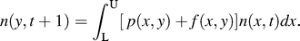

The *p*(*x,y*) kernel represents transitions of an individual of size *x* to size *y* attributable to survival, *s*, and growth, *g*, *p*(*x*, *y*) = *s*(*x*)*g*(*x*, *y*). The *f*(*x*,*y*) kernel describes per-capita production of *y*-sized individuals in the next census by reproductive individuals of size *x* (i.e., the recruit density function at the next census), *f*(*x*, *y*) = *s*(*x*)*f<sub>n</sub>*(*x*)*p*<sub>E</sub>*f*<sub>d</sub>(*y*). Here *s*(*x*) is again size-specific survival, *f<sub>n</sub>*(*x*) is the number of fruits or flowers produced by a plant of size *x*, *p*<sub>E</sub> is a constant for the estimated number of seedlings resulting per fruit, and *f*<sub>d</sub>(*y*) is the size distribution of seedlings. The growth, survival, and fertility functions are obtained from statistical models of the census data. To test our hypothesis, we constructed IPMs for three hypothetical populations: one pooling plants that were occupied solely by *P. minutula* over the course of all six surveys, one for plants occupied solely by *C. laevis*, and one for plants occupied in every survey but whose resident ant partner changed at least once. Because the low densities of some ant–plant combinations in some plots made determining plot-specific demographic functions impossible, we pooled plants from all plots to conduct our analyses; a landscape-scale analysis such as this is equivalent to constructing “summary matrices” in matrix models (sensu Horvitz and Schemske 1995, Caswell 2001) to correct for the disproportionate weight that low sample sizes can give to some transition probabilities (e.g., Bruna 2003). Because we had insufficient data to build a robust stochastic model, we also pooled data across all years of our study to represent a single average time step (sensu Miller et al. 2009). Data were prepared for analysis and models were built and analyzed with modified versions (Bruna 2014) of the IPMpack (Metcalf et al. 2013) and popbio (Stubben and Milligan 2007) packages for R (R Development Core Team 2014).

After initial analyses we were concerned that the very small number of seedlings in our study plots that were colonized by *Crematogaster laevis* was leading to inaccurate demographic functions for survivorship. To increase the number of seedlings in our demographic data set, we complemented our survey data with data from an experiment investigating the colonization rates of *M. guianensis* seedlings by queens of *P. minutula* and *C. laevis* (Bruna et al. 2011*a*). This study was conducted contemporaneously (2007) and the closest demographic plots were less than a kilometer away. The study provided data on how survivorship of *M. guianensis* seedlings over 90 days was influenced by the identity of ant occupant (see data associated with Bruna et al. 2011*b*).

Each IPM was used to calculate lambda by discretizing the kernel using the midpoint rule with 50 mesh points. The upper limit for each integration was based on the maximum size of plants in the populations being modeled, and the lower limit was constant for all populations. We also calculated the bias-corrected 95% confidence intervals for each estimate of lambda by bootstrapping (*n* = 1000 simulations) and used randomization tests (*n* = 1000 permutations) to determine if estimates of λ for populations with different ant partners were significantly different from each other (Caswell 2001, Bruna 2014).

### Life-table response experiments

To elucidate the demographic mechanisms underlying differences among populations we used life table response experiments (LTRE), which decompose differences in λ into the contributions from different demographic variables (Caswell 1989). We used a fixed-design LTRE (Caswell 2001), in which the difference in λ between two treatments, Δλ, is given by

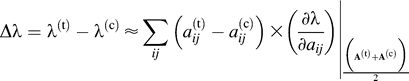

## Results

We sampled 706 *Maieta guianensis* plants over the course of our study. Plant density was significantly greater in lowlands than plateaus, although there was no difference between gaps and adjacent areas of forest within a canopy-cover type (Appendix A). Because we were attempting to isolate the effect of ant identity on plant demography, we excluded 208 plants that had no ant resident in one or more of the surveys (the effect of how long plants remain without ant partners on demography is the subject of future publications). Of the remaining 498 plants, 42 were colonized throughout solely by *Crematogatester laevis* and 398 were colonized exclusively by *Pheidole minutula*. We had 58 plants that were colonized in every survey but switched ant partners at least once (i.e., the ant resident was different in subsequent surveys). Most of these plants (74%) had only one change in resident ant species over the course of our study (single change, *N* = 43; two changes, *N* = 12; three changes, *N* = 3).

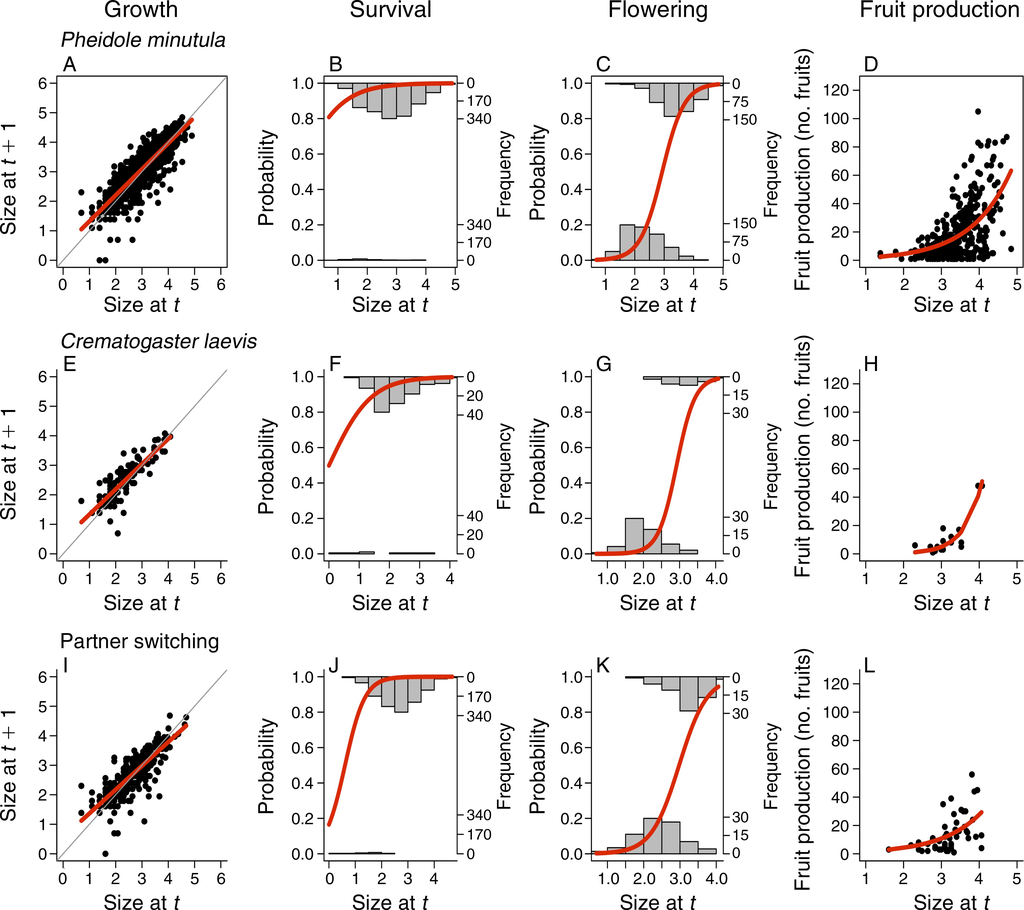

**Figure 1**

Size-dependent growth, survivorship, flowering, and fruit production of plants during initial (*t*) and subsequent (*t* + 1) surveys. Plants were either occupied throughout our study by *Pheidole minutula* (A–D), continuously by *Crematogaster laevis* (E–H), or switched partners at least once (i.e., from a given survey *t* to the subsequent survey *t* + 1) during the study period (I–L). Size is measured as ln(number of domatia).

Our LTRE analysis revealed similar demographic mechanisms were responsible for the differences in λ between all three comparisons (*P. minutula* vs. *C. laevis*, *P. minutula* vs. partner switching, and *C. laevis* vs. partner switching; Appendix C). For instance, differences in λ between populations associated with *P. minutula* and those colonized by *C. laevis* were due primarily to reduced stasis by intermediate to larger plants colonized by *C. laevis* (Appendix C). The negative contributions to Δλ along the principal diagonal, representing stasis in the largest (and reproductive) size classes far outweighed the positive ones from other regions of the matrix.

## Discussion

Despite an increasingly robust theoretical literature exploring how variation among mutualists in the benefits they provide influences the population dynamics of partners (Boucher 1985, Hoeksema and Bruna 2000, Holland et al. 2002, Ohm and Miller 2014), few empirical studies address this topic. We found that associations with different mutualist partners resulted in different population growth rates for an Amazonian host plant. Although all projections of λ were greater than one, λ was significantly greater for plants associated with one of the ant species than with the other. In addition, plants that switched partners during our study had net benefits similar to those of always associating with the poorer mutualist partner, as opposed to an intermediate value as predicted by Stanton (2003). These differences are even more striking when considering that our vales for λ are for six-month intervals as opposed to the one-year intervals more typical in studies of plant demography. Because we used deterministic models, caution must be taken not to assume our results would be identical had we conducted our study in different years (Caswell 2001), and additional survey data would allow us to estimate temporal stochasticity in λ. Nevertheless, our results underscore the importance of expanding the study of mutualisms beyond the “pair-wise perspective” (sensu Stanton 2003) to consider the costs and benefits of interacting with different putative partners. Considering the long-term demographic consequences of these costs and benefits will greatly enhance our ability to generalize about how mutualisms evolve and persist (Bruna et al. 2008, Palmer et al. 2010).

What are the demographic mechanisms underlying the lower growth rates of populations housing *C. laevis* or switching partners? Life-table response experiments indicate that the differences in λ are due primarily to differences in the probability of growing into or remaining in large size classes (Appendix C), which are those that are most likely to reproduce and produce the most fruit when they do (Fig. 1). These results are consistent with those of short-term experiments and previous observations. Plants with *C. laevis* are smaller than those with *P. minutula* (Vasconcelos and Davidson 2000)*,* and *C. laevis* respond more slowly and at lower intensity to cues associated with herbivory (Lapola et al. 2003). They also house more trophobionts inside domatia (Lapola et al. 2005), which at high densities could conceivably reduce the growth of plants (Heil and McKey 2003). Finally, experimental removal of ants from *M. guianensis* greatly increased herbivory and reduced fruit set (Vasconcelos 1991), which is consistent with results from sympatric and closely related systems (Bruna et al. 2004). Although recent meta-analyses have argued that herbivore damage is not a reliable surrogate for fitness consequences of ant-protection (Trager et al. 2010), our results suggest that differences among ant species in the costs and benefits they provide, even small ones, can indeed interact in subtle ways that affect λ.

Finally, we provide some of the first demographic evidence to date that associating with multiple partners reduces the net benefits to host plants. While prior simulation studies have provided support for this idea (Bronstein et al. 2003, Miller 2007), the most comprehensive empirical work to date has found the opposite to be true. Palmer et al. (2010) found that, for African *Acacia drepanolobium* trees, λ was lower for hypothetical populations interacting with only one ant partner than for populations successively colonized by four different ant species, even though one ant species is a sterilization parasite that inhibits reproduction and another reduces tree survivorship. They argued that this counterintuitive effect is due to trade-offs between survivorship and fecundity at different stages of the tree life-cycle facilitated by the different life spans of the trees and their partners. Our results suggest the extent to which multiple sequential partners are detrimental or beneficial in ant–plant mutualisms varies among ant–plant systems. In our study system, there is no sterilizing ant partner that enhances plant growth at the expense of reproduction; mutualists that sterilize a partner species have garnered considerable interest (e.g., Izzo and Vasconcelos 2002, Frederickson 2009) but appear rare among ant–plant mutualisms. Indeed, there is no a priori reason to expect that the effects of temporal changes in partner identity should be inherently beneficial or detrimental. Instead, Jensen's inequality (Karban et al. 1997, Inouye 2005) predicts that the mean benefits will depend on the functional form of the relationship between frequency of partner identity and λ, and this relationship is likely to vary among plant species as the number and quality of mutualist partners changes.

## Acknowledgments

We thank T. Caughlin and two anonymous reviewers for comments on the manuscript and E. Z. de Albuquerque and O. F. da Silva for assistance in the field. Financial support was provided by Brazil's CNPq (Grants 552680/2006-0 and 490518/2006-0), and the U.S. NSF (grants DEB-0452720 and DEB-0453631). This is publication number 650 in the BDFFP technical series.

## Supplementary Material

**Ecological Archives**

Appendices A–C are available online: http://dx.doi.org/10.1890/14-0481.1.sm

**Data Availability**

Data associated with this paper have been deposited in Dryad: [http://dx.doi.org/dryad.5kc45](http://dx.doi.org/10.5061/dryad.5kc45)

## Citing Literature

[Volume95, Issue12](https://esajournals.onlinelibrary.wiley.com/toc/19399170/2014/95/12)

December 2014

Pages 3237-3243